# Pregunta1

1. Introducción, la idea es conectar la descomposión espectral de la matriz de varianzas como una alternativa a encontrar los ejes nuevos de una elipse rotada así como el valor de los semiejes de tal modo que la forma cuadrática de la varianza sea equivalente a la ecuación de una elipse con centro en los nuevos ejes. primero sea
   $$\Sigma =\begin{pmatrix}
   \sigma_{x}^2 & \sigma_{xy} \\
   \sigma_{xy} & \sigma_{y}^2
   \end{pmatrix}
   \quad$$
   la matriz de varianzas y covarianzas de las variables $x,y$ , de forma más simple veamos la curva de nivel 1 de la forma cuadrática de la matriz, entonces $x^T \Sigma x=1$ significa en términos más simples $x^2\sigma_{x}^2+2xy\sigma_{xy}+y^2\sigma_{y}^2=1$ y esta expresión no es otra cosa más que la ecuación de una elipse ROTADA.

Por los puntos anteriormente expuestos podemos conectar que en el caso bidimensional la descomposición espectral de la matriz $\Sigma$ nos da la rotación y dirección de los nuevos ejes usando los eigenvectores de la matriz $P$ y las magnitudes o eigenvalores $diag(D)$ con
$$D=\begin{pmatrix}
\sigma_{x'}^2 & 0\\
0& \sigma_{y'}^2
\end{pmatrix}
\quad$$
de tal modo que la diagonalización de $\Sigma$ nos lleva a encontrar la matriz de rotación de los ejes $P$ tal que se dé la relación
$$(x,y)=P(x',y')$$
y esta matriz
$$P=\begin{pmatrix}
cos\theta & -sen\theta\\
sen\theta& cos\theta
\end{pmatrix}
\quad$$

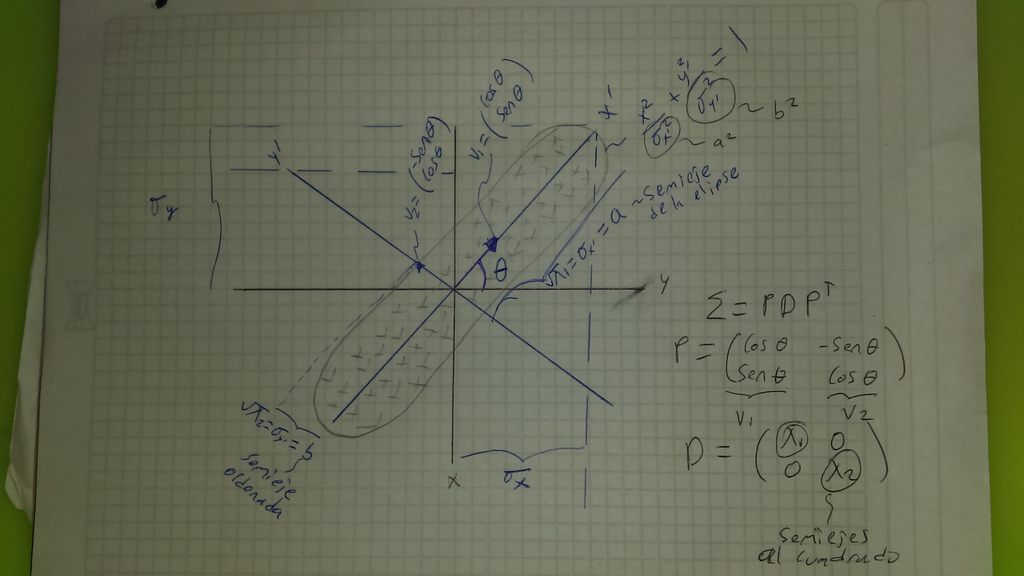

Conclusión descomponer la matriz de varianzas bidimensional en su forma espectral nos da los nuevos ejes de una elipse rotada así como la magnitud de sus semiejes que no es otra cosa que las desviaciones estándar(ó un múltiplo de ella)de este modo podemos expresar la ecuación de una elipse rotada como descomposición espectral.

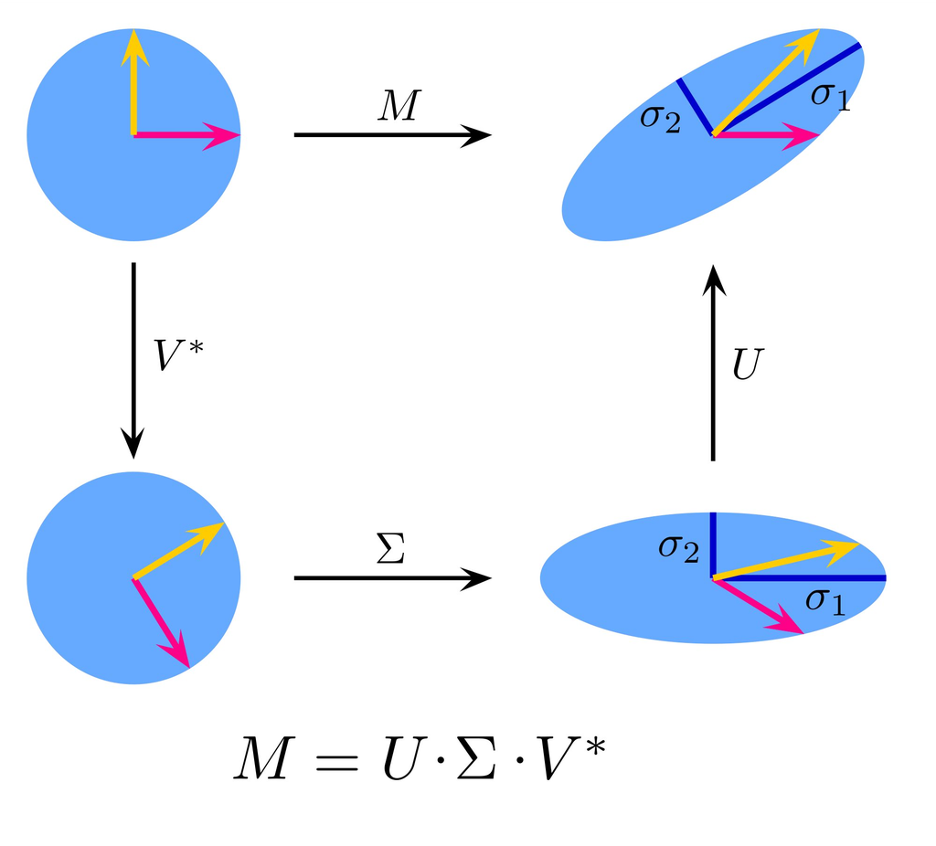

la interpetación geométrica de SVD no es otra más que como se muestra en la figura, vemos que multiplicar por la matriz $V^*$ ortogonal significa una rotación de ejes, luego al multiplicar por la matriz diagonal $\Sigma$ lo que sucede es un redimensionamiento de los ejes canónicos y finalmente al multiplicar por $U$ se hace una rotación nuevamente pero de la elipse. análogamente sucede similar para el tema de diagonalización

3. Suponiendo que la matriz A es centrada y $\Sigma(A)={\frac{1}{n}}A^TA$, entonces sea la descomposición SVD de $A=U \Sigma V^T$ tal que $U,V$ son matrices ortogonales y $\Sigma$ es una matriz casi diagonal salvo por el excedente de dimensiones y con diagonal mayor que cero. entonces
   $$\Sigma(A)={\frac{1}{n}}A^TA={\frac{1}{n}}(U \Sigma V^T)^T(U \Sigma V^T)\\
   ={\frac{1}{n}}V \Sigma^T (U^TU) \Sigma V^T\ \ \ \ (U^TU)=I\ \ por\ ortogonalidad\\
   ={\frac{1}{n}}V \Sigma^T \Sigma V^T\\
   entonces\ {\frac{1}{n}}A^TA={\frac{1}{n}}V \Sigma^T \Sigma V^T\\
   y\ V^TA^TAV=\Sigma^T \Sigma$$
   y dado que $\Sigma$ es una matriz de $mxn$ diagonal entonces $\Sigma^T \Sigma$ es una matriz diagonal de $nxn$ cuyas entradas diagonales son las mismas de $\Sigma$ pero al cuadrado. entonces se ha encontrado una diagonalización de la matriz ${\frac{1}{n}}A^TA$ y los eigenvalores correspondientes son ${\frac{\lambda_{i}^2}{n}}=(\Sigma^T \Sigma)_{ii}$ y por tanto $(\Sigma_{ii}={\frac{\lambda_{i}}{\sqrt n}})$ entonces los valores de la matriz $\Sigma$ de valores singulares de $A$ son las raices de los valores positivos de $\Sigma(A)$ notar que las columnas de $V$ son los eigenvectores de $\Sigma(A)$ puesto que dado que $V^TA^TAV=\Sigma^T \Sigma$ entonces $A^TAV=\Sigma^T \Sigma V$. por tanto la relación de SVD de $A$ y la diagonalización de su matriz de covarianzas es que $V$ es la matriz de eigenvectores de $\Sigma(A)$ y los eigenvalores de $\Sigma(A)$ son el cuadrado de los valores singulares de $A$.